# Case Study 2: DDS

Aniketh V

4/13/2020

# Attrition and Income- Frito Lays

## Executive Summary

In this Rmarkdown file you will find analysis for Frito Lays from the data that was presented to our company. After reviewing this file, you will gain a better understanding of the some of the data including Monthly Income and Attrition. It will also include some bonuses that gives a look into some trends that Frito-Lays might find useful. The document will be wrapped up with the models and predictions that came about those models.

## Introduction

Greetings! Today we will be discussing “Attrition and Income” too check what leads to attrition and income levels for talent management.

## Setting up the environment

```r
#Loading in the required libraries
library(stringr)
library(dplyr)
library(plyr)
```

```r
library(magrittr)
library(ggplot2)
library(tidyr)
library(GGally)
library(ggalt)
library(mice)
library(e1071)
library(class)
library(caret)
library(ggcorrplot)

#Reading in the data
attritionData = read.csv("/Users/password1234/Documents/Doing_Data_Science/MSDS_6306_Doing-Data-Science/Unit\ 14\ and\ 15\ Case\ Study\ 2/CaseStudy2-data.csv", header = TRUE)
noAttritionData = read.csv("/Users/password1234/Documents/Doing_Data_Science/MSDS_6306_Doing-Data-Science/Unit\ 14\ and\ 15\ Case\ Study\ 2/CaseStudy2CompSet\ No\ Attrition.csv", header = TRUE)
noSalaryData = read.csv("/Users/password1234/Documents/Doing_Data_Science/MSDS_6306_Doing-Data-Science/Unit\ 14\ and\ 15\ Case\ Study\ 2/CaseStudy2CompSet\ No\ Salary.csv", header = TRUE)

#Get a look at the summary for the attrition data
summary(attritionData)
```

```
##        ID             Age        Attrition           BusinessTravel
##  Min.   :  1.0   Min.   :18.00   No :730   Non-Travel       : 94
##  1st Qu.:218.2   1st Qu.:30.00   Yes:140   Travel_Frequently:158
##  Median :435.5   Median :35.00             Travel_Rarely    :618
##  Mean   :435.5   Mean   :36.83
##  3rd Qu.:652.8   3rd Qu.:43.00
##  Max.   :870.0   Max.   :60.00
##
##    DailyRate                       Department  DistanceFromHome
##  Min.   : 103.0   Human Resources       : 35   Min.   : 1.000
##  1st Qu.: 472.5   Research & Development:562   1st Qu.: 2.000
##  Median : 817.5   Sales                 :273   Median : 7.000
##  Mean   : 815.2                                Mean   : 9.339
##  3rd Qu.:1165.8                                3rd Qu.:14.000
##  Max.   :1499.0                                Max.   :29.000
##
##    Education              EducationField EmployeeCount EmployeeNumber
##  Min.   :1.000   Human Resources : 15    Min.   :1     Min.   :   1.0
##  1st Qu.:2.000   Life Sciences   :358    1st Qu.:1     1st Qu.: 477.2
##  Median :3.000   Marketing       :100    Median :1     Median :1039.0
##  Mean   :2.901   Medical         :270    Mean   :1     Mean   :1029.8
##  3rd Qu.:4.000   Other           : 52    3rd Qu.:1     3rd Qu.:1561.5
##  Max.   :5.000   Technical Degree: 75    Max.   :1     Max.   :2064.0
##
##  EnvironmentSatisfaction    Gender      HourlyRate     JobInvolvement
##  Min.   :1.000           Female:354   Min.   : 30.00   Min.   :1.000
##  1st Qu.:2.000           Male  :516   1st Qu.: 48.00   1st Qu.:2.000
##  Median :3.000                        Median : 66.00   Median :3.000
##  Mean   :2.701                        Mean   : 65.61   Mean   :2.723
##  3rd Qu.:4.000                        3rd Qu.: 83.00   3rd Qu.:3.000
##  Max.   :4.000                        Max.   :100.00   Max.   :4.000
##
##     JobLevel                          JobRole    JobSatisfaction
##  Min.   :1.000   Sales Executive          :200   Min.   :1.000
##  1st Qu.:1.000   Research Scientist       :172   1st Qu.:2.000
##  Median :2.000   Laboratory Technician    :153   Median :3.000
##  Mean   :2.039   Manufacturing Director   : 87   Mean   :2.709
##  3rd Qu.:3.000   Healthcare Representative: 76   3rd Qu.:4.000
##  Max.   :5.000   Sales Representative     : 53   Max.   :4.000
##                  (Other)                  :129
```

[output cut: 25 more lines]

```
##  Min.   :1.000   Min.   : 0.000   Min.   : 0.000
##  1st Qu.:2.000   1st Qu.: 3.000   1st Qu.: 2.000
##  Median :3.000   Median : 5.000   Median : 3.000
##  Mean   :2.782   Mean   : 6.962   Mean   : 4.205
##  3rd Qu.:3.000   3rd Qu.:10.000   3rd Qu.: 7.000
##  Max.   :4.000   Max.   :40.000   Max.   :18.000
##
##  YearsSinceLastPromotion YearsWithCurrManager
##  Min.   : 0.000          Min.   : 0.00
##  1st Qu.: 0.000          1st Qu.: 2.00
##  Median : 1.000          Median : 3.00
##  Mean   : 2.169          Mean   : 4.14
##  3rd Qu.: 3.000          3rd Qu.: 7.00
##  Max.   :15.000          Max.   :17.00
##
```

```r
summary(noAttritionData)
```

```
##        ID            Age                  BusinessTravel   DailyRate
##  Min.   :1171   Min.   :19.00   Non-Travel       : 32    Min.   : 102.0
##  1st Qu.:1246   1st Qu.:31.00   Travel_Frequently: 57    1st Qu.: 448.0
##  Median :1320   Median :36.00   Travel_Rarely    :211    Median : 775.0
##  Mean   :1320   Mean   :37.86                            Mean   : 784.8
##  3rd Qu.:1395   3rd Qu.:44.00                            3rd Qu.:1117.0
##  Max.   :1470   Max.   :60.00                            Max.   :1490.0
##
##                   Department  DistanceFromHome   Education
##  Human Resources       : 11   Min.   : 1.00    Min.   :1.000
##  Research & Development:209   1st Qu.: 2.00    1st Qu.:2.000
##  Sales                 : 80   Median : 7.00    Median :3.000
##                               Mean   : 9.26    Mean   :2.973
##                               3rd Qu.:14.00    3rd Qu.:4.000
##                               Max.   :29.00    Max.   :5.000
##
##           EducationField EmployeeCount EmployeeNumber
##  Human Resources :  7    Min.   :1     Min.   :   2.0
##  Life Sciences   :130    1st Qu.:1     1st Qu.: 508.8
##  Marketing       : 27    Median :1     Median : 994.5
##  Medical         : 94    Mean   :1     Mean   :1020.9
##  Other           : 12    3rd Qu.:1     3rd Qu.:1542.5
##  Technical Degree: 30    Max.   :1     Max.   :2065.0
##
##  EnvironmentSatisfaction    Gender      HourlyRate     JobInvolvement
##  Min.   :1.000           Female:105   Min.   : 30.00   Min.   :1.000
##  1st Qu.:2.000           Male  :195   1st Qu.: 50.00   1st Qu.:2.000
##  Median :3.000                        Median : 66.00   Median :3.000
##  Mean   :2.733                        Mean   : 66.07   Mean   :2.743
##  3rd Qu.:4.000                        3rd Qu.: 83.00   3rd Qu.:3.000
##  Max.   :4.000                        Max.   :100.00   Max.   :4.000
##
##     JobLevel                        JobRole   JobSatisfaction
##  Min.   :1.0   Research Scientist       :61   Min.   :1.000
##  1st Qu.:1.0   Sales Executive          :57   1st Qu.:2.000
##  Median :2.0   Laboratory Technician    :55   Median :3.000
##  Mean   :2.2   Manufacturing Director   :31   Mean   :2.767
##  3rd Qu.:3.0   Manager                  :30   3rd Qu.:4.000
##  Max.   :5.0   Healthcare Representative:29   Max.   :4.000
##                (Other)                  :37
```

[output cut: 25 more lines]

```
##  Min.   :1.000   Min.   : 0.000   Min.   : 0.00
##  1st Qu.:2.000   1st Qu.: 3.000   1st Qu.: 2.00
##  Median :3.000   Median : 5.000   Median : 3.00
##  Mean   :2.747   Mean   : 7.527   Mean   : 4.33
##  3rd Qu.:3.000   3rd Qu.:10.000   3rd Qu.: 7.00
##  Max.   :4.000   Max.   :37.000   Max.   :18.00
##
##  YearsSinceLastPromotion YearsWithCurrManager
##  Min.   : 0.00           Min.   : 0.00
##  1st Qu.: 0.00           1st Qu.: 2.00
##  Median : 1.00           Median : 3.00
##  Mean   : 2.29           Mean   : 4.38
##  3rd Qu.: 3.00           3rd Qu.: 7.00
##  Max.   :15.00           Max.   :17.00
##
```

## Exploratory Data Analysis

As part of the first step we would like to take a rough look at the data at hand. We want to do some intial analysis to see if anything catches our eye. Additionally, we will take a look at the data types for the variables to see what we are working with.

Couple of quick notes (as per a preliminary analysis): - Standard hours is 80 across the board - Over 18 is also “Y” across the board - Employee count is only 1

```r
#View the data types for each variable we are dealing with
dplyr::glimpse(attritionData)
```

```
## Observations: 870
## Variables: 36
## $ ID                       <int> 1, 2, 3, 4, 5, 6, 7, 8, 9, 10, 11, 12, …
## $ Age                      <int> 32, 40, 35, 32, 24, 27, 41, 37, 34, 34,…
## $ Attrition                <fct> No, No, No, No, No, No, No, No, No, No,…
## $ BusinessTravel           <fct> Travel_Rarely, Travel_Rarely, Travel_Fr…
## $ DailyRate                <int> 117, 1308, 200, 801, 567, 294, 1283, 30…
## $ Department               <fct> Sales, Research & Development, Research…
## $ DistanceFromHome         <int> 13, 14, 18, 1, 2, 10, 5, 10, 10, 10, 6,…
## $ Education                <int> 4, 3, 2, 4, 1, 2, 5, 4, 4, 4, 3, 2, 3, …
## $ EducationField           <fct> Life Sciences, Medical, Life Sciences, …
## $ EmployeeCount            <int> 1, 1, 1, 1, 1, 1, 1, 1, 1, 1, 1, 1, 1, …
## $ EmployeeNumber           <int> 859, 1128, 1412, 2016, 1646, 733, 1448,…
## $ EnvironmentSatisfaction  <int> 2, 3, 3, 3, 1, 4, 2, 4, 3, 4, 1, 3, 3, …
## $ Gender                   <fct> Male, Male, Male, Female, Female, Male,…
```

[output cut: 23 more lines]

```r
#Separate the numerical and categorical variables in the dataframe
sapply(attritionData, is.factor)
```

```
##                       ID                      Age                Attrition
##                    FALSE                    FALSE                     TRUE
##           BusinessTravel                DailyRate               Department
##                     TRUE                    FALSE                     TRUE
##         DistanceFromHome                Education           EducationField
##                    FALSE                    FALSE                     TRUE
##            EmployeeCount           EmployeeNumber  EnvironmentSatisfaction
##                    FALSE                    FALSE                    FALSE
##                   Gender               HourlyRate           JobInvolvement
##                     TRUE                    FALSE                    FALSE
##                 JobLevel                  JobRole          JobSatisfaction
##                    FALSE                     TRUE                    FALSE
##            MaritalStatus            MonthlyIncome              MonthlyRate
##                     TRUE                    FALSE                    FALSE
##       NumCompaniesWorked                   Over18                 OverTime
##                    FALSE                     TRUE                     TRUE
##        PercentSalaryHike        PerformanceRating RelationshipSatisfaction
##                    FALSE                    FALSE                    FALSE
##            StandardHours         StockOptionLevel        TotalWorkingYears
##                    FALSE                    FALSE                    FALSE
##    TrainingTimesLastYear          WorkLifeBalance           YearsAtCompany
##                    FALSE                    FALSE                    FALSE
##       YearsInCurrentRole  YearsSinceLastPromotion     YearsWithCurrManager
##                    FALSE                    FALSE                    FALSE
```

```r
#Categorical variables only
categoricalVar = attritionData[,sapply(attritionData, is.factor)]
summary(categoricalVar)
```

```
##  Attrition           BusinessTravel                  Department
##  No :730   Non-Travel       : 94    Human Resources       : 35
##  Yes:140   Travel_Frequently:158    Research & Development:562
##            Travel_Rarely    :618    Sales                 :273
##
##
##
##
##           EducationField    Gender                         JobRole
##  Human Resources : 15    Female:354   Sales Executive          :200
##  Life Sciences   :358    Male  :516   Research Scientist       :172
##  Marketing       :100                 Laboratory Technician    :153
##  Medical         :270                 Manufacturing Director   : 87
##  Other           : 52                 Healthcare Representative: 76
##  Technical Degree: 75                 Sales Representative     : 53
##                                       (Other)                  :129
##   MaritalStatus Over18  OverTime
##  Divorced:191   Y:870   No :618
##  Married :410           Yes:252
##  Single  :269
##
##
##
##
```

```r
#Numerical variables only
numericalVar = attritionData[,!sapply(attritionData, is.factor)]
summary(numericalVar)
```

```
##        ID             Age          DailyRate      DistanceFromHome
##  Min.   :  1.0   Min.   :18.00   Min.   : 103.0   Min.   : 1.000
##  1st Qu.:218.2   1st Qu.:30.00   1st Qu.: 472.5   1st Qu.: 2.000
##  Median :435.5   Median :35.00   Median : 817.5   Median : 7.000
##  Mean   :435.5   Mean   :36.83   Mean   : 815.2   Mean   : 9.339
##  3rd Qu.:652.8   3rd Qu.:43.00   3rd Qu.:1165.8   3rd Qu.:14.000
##  Max.   :870.0   Max.   :60.00   Max.   :1499.0   Max.   :29.000
##    Education     EmployeeCount EmployeeNumber   EnvironmentSatisfaction
##  Min.   :1.000   Min.   :1     Min.   :   1.0   Min.   :1.000
##  1st Qu.:2.000   1st Qu.:1     1st Qu.: 477.2   1st Qu.:2.000
##  Median :3.000   Median :1     Median :1039.0   Median :3.000
##  Mean   :2.901   Mean   :1     Mean   :1029.8   Mean   :2.701
##  3rd Qu.:4.000   3rd Qu.:1     3rd Qu.:1561.5   3rd Qu.:4.000
##  Max.   :5.000   Max.   :1     Max.   :2064.0   Max.   :4.000
##    HourlyRate     JobInvolvement     JobLevel     JobSatisfaction
##  Min.   : 30.00   Min.   :1.000   Min.   :1.000   Min.   :1.000
##  1st Qu.: 48.00   1st Qu.:2.000   1st Qu.:1.000   1st Qu.:2.000
##  Median : 66.00   Median :3.000   Median :2.000   Median :3.000
##  Mean   : 65.61   Mean   :2.723   Mean   :2.039   Mean   :2.709
##  3rd Qu.: 83.00   3rd Qu.:3.000   3rd Qu.:3.000   3rd Qu.:4.000
##  Max.   :100.00   Max.   :4.000   Max.   :5.000   Max.   :4.000
##  MonthlyIncome    MonthlyRate    NumCompaniesWorked PercentSalaryHike
##  Min.   : 1081   Min.   : 2094   Min.   :0.000      Min.   :11.0
##  1st Qu.: 2840   1st Qu.: 8092   1st Qu.:1.000      1st Qu.:12.0
##  Median : 4946   Median :14074   Median :2.000      Median :14.0
##  Mean   : 6390   Mean   :14326   Mean   :2.728      Mean   :15.2
##  3rd Qu.: 8182   3rd Qu.:20456   3rd Qu.:4.000      3rd Qu.:18.0
##  Max.   :19999   Max.   :26997   Max.   :9.000      Max.   :25.0
##  PerformanceRating RelationshipSatisfaction StandardHours StockOptionLevel
##  Min.   :3.000     Min.   :1.000            Min.   :80    Min.   :0.0000
##  1st Qu.:3.000     1st Qu.:2.000            1st Qu.:80    1st Qu.:0.0000
##  Median :3.000     Median :3.000            Median :80    Median :1.0000
##  Mean   :3.152     Mean   :2.707            Mean   :80    Mean   :0.7839
##  3rd Qu.:3.000     3rd Qu.:4.000            3rd Qu.:80    3rd Qu.:1.0000
##  Max.   :4.000     Max.   :4.000            Max.   :80    Max.   :3.0000
##  TotalWorkingYears TrainingTimesLastYear WorkLifeBalance YearsAtCompany
##  Min.   : 0.00     Min.   :0.000         Min.   :1.000   Min.   : 0.000
##  1st Qu.: 6.00     1st Qu.:2.000         1st Qu.:2.000   1st Qu.: 3.000
##  Median :10.00     Median :3.000         Median :3.000   Median : 5.000
##  Mean   :11.05     Mean   :2.832         Mean   :2.782   Mean   : 6.962
##  3rd Qu.:15.00     3rd Qu.:3.000         3rd Qu.:3.000   3rd Qu.:10.000
##  Max.   :40.00     Max.   :6.000         Max.   :4.000   Max.   :40.000
##  YearsInCurrentRole YearsSinceLastPromotion YearsWithCurrManager
##  Min.   : 0.000     Min.   : 0.000          Min.   : 0.00
##  1st Qu.: 2.000     1st Qu.: 0.000          1st Qu.: 2.00
##  Median : 3.000     Median : 1.000          Median : 3.00
##  Mean   : 4.205     Mean   : 2.169          Mean   : 4.14
##  3rd Qu.: 7.000     3rd Qu.: 3.000          3rd Qu.: 7.00
##  Max.   :18.000     Max.   :15.000          Max.   :17.00
```

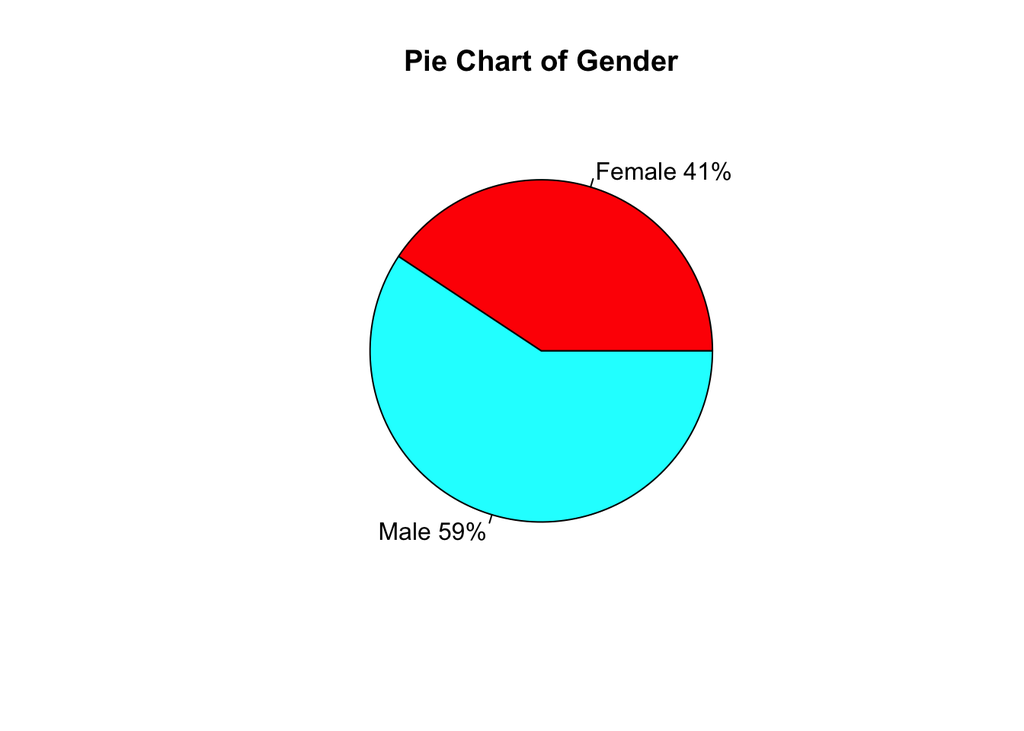

```r
table1 = data.frame(Gender = count(attritionData$Gender))
table2 = data.frame(Attrition = count(attritionData$Attrition))
oneDf = cbind(table1, table2)
oneDf$AtrritionPerc = oneDf$Attrition.freq/870
oneDf$GenderPerc = oneDf$Gender.freq/870
oneDf$AtrritionPerc = round(oneDf$AtrritionPerc,2)
oneDf$GenderPerc = round(oneDf$GenderPerc,2)

pct = round(oneDf$GenderPerc*100)
lbls = paste(oneDf$Gender.x, pct)
lbls = paste(lbls,"%", sep = "")
pie(oneDf$Gender.freq, labels = lbls, col = rainbow(length(lbls)), main = "Pie Chart of Gender")
```

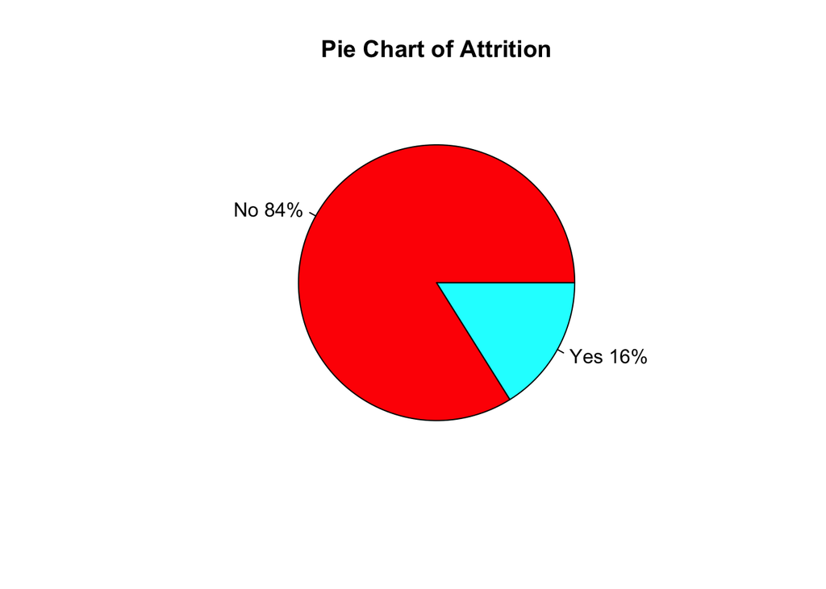

```r
pct1 = round(oneDf$AtrritionPerc*100)
lbls1 = paste(oneDf$Attrition.x, pct1)
lbls1 = paste(lbls1,"%", sep = "")
pie(oneDf$Attrition.freq, labels = lbls1, col = rainbow(length(lbls1)), main = "Pie Chart of Attrition")
```

```r
#Observing numerical variables that we can use to predict monthly income for linear regression equation.
corr = round(cor(numericalVar), 1)
```

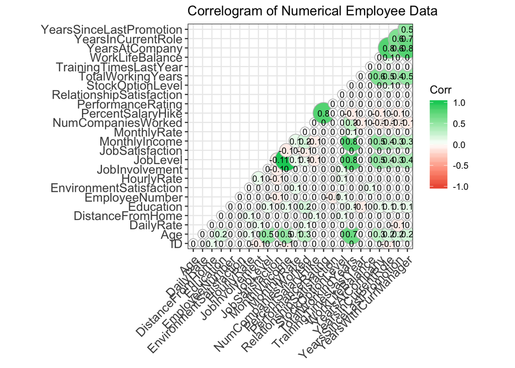

```r
ggcorrplot(corr, hc.method = TRUE,
           type = "lower",
           lab = TRUE,
           lab_size = 3,
           method = "circle",
           colors = c("tomato2", "white", "springgreen3"),
           title = "Correlogram of Numerical Employee Data",
           ggtheme = theme_bw)
```

Looks like there are only 9 categorical variables in the dataset and around 28 for numerical variables. This will mean we would want to do some dummy coding later when we decide the attrition factors.

## Finding Attrition Factors

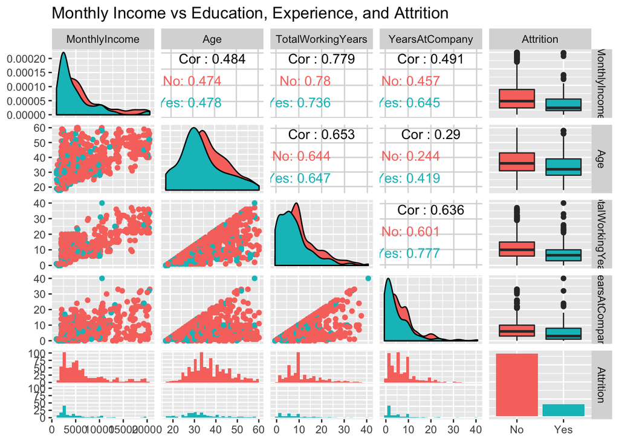

```r
###Lets look at a rough analysis on multiple different columns to see if we can figure something out
attritionData %>% select(MonthlyIncome, Age, TotalWorkingYears, YearsAtCompany, Attrition) %>% ggpairs(mapping = aes(color = Attrition)) + ggtitle("Monthly Income vs Education, Experience, and Attrition")
```

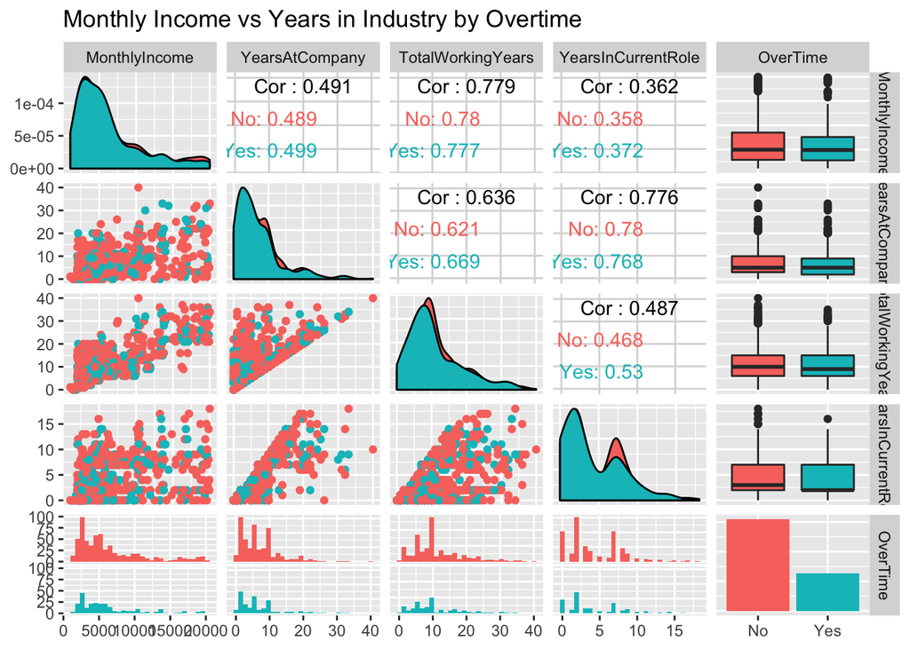

```r
attritionData %>% select(MonthlyIncome, YearsAtCompany, TotalWorkingYears, YearsInCurrentRole, OverTime) %>% ggpairs(mapping = aes(color = OverTime)) + ggtitle("Monthly Income vs Years in Industry by Overtime")
```

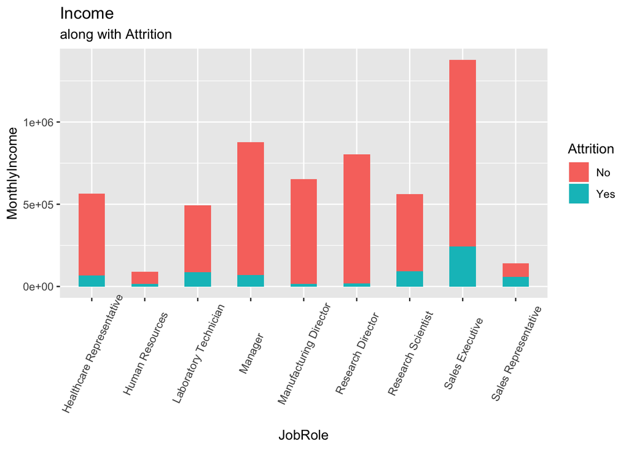

```r
#Lets look at if Monthyly income and Job Role play a role in determining Attrition
attritionData %>% ggplot(aes(x = JobRole, y = MonthlyIncome, fill = Attrition)) + geom_bar(stat = "identity", width = .5) + labs(title = "Income", subtitle = "along with Attrition") + theme(axis.text.x = element_text(angle = 65, vjust = 0.6))
```

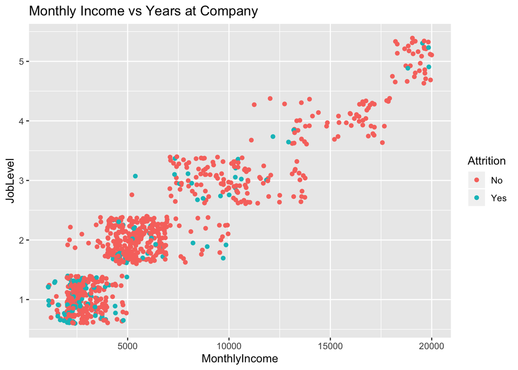

```r
#Plotting monthly income and years at company, color coating by job role
attritionData %>% ggplot(aes(x = MonthlyIncome, y = JobLevel, color = Attrition)) + geom_point(position = "jitter") + ggtitle("Monthly Income vs Years at Company")
```

```r
summary(attritionData$Age)
```

```
##    Min. 1st Qu.  Median    Mean 3rd Qu.    Max.
##   18.00   30.00   35.00   36.83   43.00   60.00
```

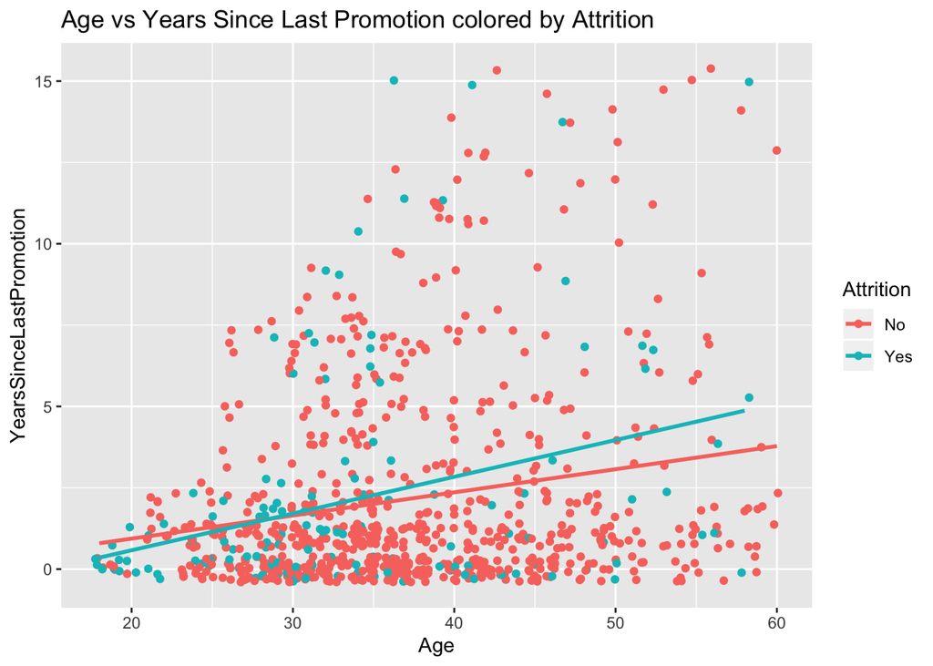

```r
#I want to see what relationship age and years since last promotion have with attrition. Does the age and the years since last promotion affect attrition?
attritionData %>% ggplot(aes(x = Age, y = YearsSinceLastPromotion, color = Attrition)) + geom_point(position = "jitter") + geom_smooth(method = "lm", se = F) + ggtitle("Age vs Years Since Last Promotion colored by Attrition")
```

```r
#Creating an new column with age groups the ages fall under
attritionData = attritionData %>% mutate(ageGroup = case_when(Age >=18 & Age <= 30 ~ '18-30',
                                         Age >=31 & Age <= 45 ~ '31-45',
                                         Age >=46 & Age <= 60 ~ '46-60'))
count(attritionData, "ageGroup")
```

```
##   ageGroup freq
## 1    18-30  222
## 2    31-45  491
## 3    46-60  157
```

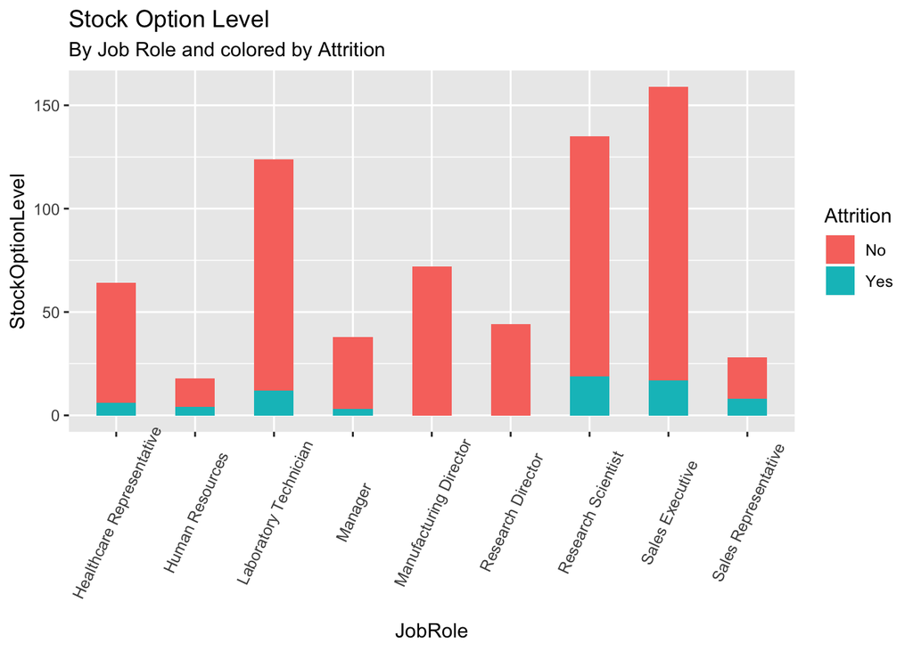

```r
#Tallying the number for Attrition for Yes and No
ageCountFinal = attritionData %>% group_by(Attrition, ageGroup) %>% tally()

#Rounding
ageCountFinal = ageCountFinal %>% mutate(Perc = n/870)
ageCountFinal$Perc = round(ageCountFinal$Perc*100, digits = 3)

#Failed attempt to create a pie chart
attritionData %>% ggplot(aes(x = JobRole, y = StockOptionLevel, fill = Attrition)) + geom_bar(stat = "identity", width = .5) + labs(title = "Stock Option Level", subtitle = "By Job Role and colored by Attrition") + theme(axis.text.x = element_text(angle = 65, vjust = 0.6))
```

At a glance, it looks like age and years since last promotion do play a big role for turnover/attrition. As per the final graph there seems to be some information that tells us that there are many young people that seem to leave the company. At 0 since years since last promotion, this tells me that they have not been working in the company as long.

Final picks: Age - 6.6% Attrition perc for employees 18-30 - 7.2% Attrition perc for employees 31-45 - 2.3% Attrition perc for employees 45-60 YearSinceLastPromotion - Wild Card, has a mixed bag of attrition rates as per the graph StockOptionLevel - The higher positions, such as researchers and executives have the most stock options and the higher attrition rate per the other job posts - Possibly leave once their portfolio matures at the company, to make a passive income.

# Interesting Facts/Trend

There was also an interesting trend that was noticed as something that is interesting. As per the bar chart it looks like the most satisfying job is the Sales Executive Job. Human resources specialists and managers seem to have the lower job satisfaction. There is definitely more men than women that filled some of these roles.

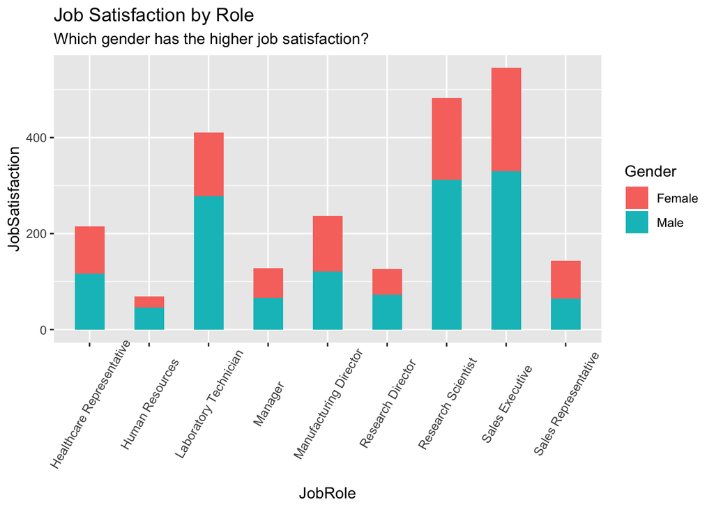

```r
attritionData %>% ggplot(aes(x = JobRole, y = JobSatisfaction, fill = Gender)) + geom_bar(stat = "identity", width = .5) + labs(title = "Job Satisfaction by Role", subtitle = "Which gender has the higher job satisfaction?") + theme(axis.text.x = element_text(angle = 60, vjust = 0.6))
```

## Attrition - KNN

We identified our top three factors to determine Attrition. In this data set the Attrition factors are not proportionate, if you try different combos of variables it is hard to achieve the 60/60 split. The below variables are some that were found to affect attrition and are my pick for top 3. - Age - Stock Option Level - Years since last promotion

```r
#Filtering out Attrition by Yes and No
atrritionYes = attritionData %>% filter(Attrition == "Yes")
attritionNo = attritionData %>% filter(Attrition == "No")

# set.seed(0)
# splitPerc = .70
# trainIndices = sample(1:dim(atrritionYes)[1], round(splitPerc * dim(atrritionYes)[1]))
# train = atrritionYes[trainIndices,]
# test = atrritionYes[-trainIndices,]
#
# set.seed(6)
# splitPerc = .70
# trainIndices2 = sample(1:dim(attritionNo)[1], round(splitPerc * dim(attritionNo)[1]))
# train1 = attritionNo[trainIndices2,]
# test1 = attritionNo[-trainIndices2,]
#
#
# train_final = rbind(train1, train)
# test_final = rbind(test1, test)
# final_data = rbind(train,train1,test, test1)
# oneTime = rbind(train_final, test_final)
#
# set.seed(0)
# splitPerc = .70
# trainIndices3 = sample(1:dim(attritionData)[1], round(splitPerc * dim(attritionData)[1]))
# train3 = attritionData[trainIndices3,]
# test3 = attritionData[-trainIndices3,]


#Need to dummy code Business Travel, if needed later. Its one of the categories that I believed plays a role in attrition. It will be needed later on if we decide to test out different combonations.
attritionData$Travel_Num = str_replace(attritionData$BusinessTravel, "Travel_Rarely", "1")
attritionData$Travel_Num = str_replace(attritionData$Travel_Num, "Travel_Frequently", "2")
attritionData$Travel_Num = str_replace(attritionData$Travel_Num, "Non-Travel", "0")
attritionData$Travel_Num = as.integer(attritionData$Travel_Num)

#Use later for test data
noAttr = noAttritionData %>% select(ID, Age, StockOptionLevel, YearsSinceLastPromotion)
#Lets do KNN
case = attritionData %>% select(ID, Age, StockOptionLevel, YearsSinceLastPromotion, Attrition) %>% group_by(ID)
#For predicting our classification to the competition set.
attr_pred = knn(case[,c(2,3,4)], noAttr[,c(2,3,4)], case$Attrition, k = 13, prob = TRUE)
noAttr$Attrition = attr_pred
confusionMatrix(table(attr_pred, noAttr$Attrition))
```

```
## Confusion Matrix and Statistics
##
##
## attr_pred  No Yes
##       No  293   0
##       Yes   0   7
##
##                Accuracy : 1
##                  95% CI : (0.9878, 1)
##     No Information Rate : 0.9767
##     P-Value [Acc > NIR] : 0.0008393
##
##                   Kappa : 1
##
##  Mcnemar's Test P-Value : NA
##
##             Sensitivity : 1.0000
##             Specificity : 1.0000
##          Pos Pred Value : 1.0000
##          Neg Pred Value : 1.0000
##              Prevalence : 0.9767
##          Detection Rate : 0.9767
##    Detection Prevalence : 0.9767
##       Balanced Accuracy : 1.0000
##
##        'Positive' Class : No
##
```

```r
predictionsAttrition = noAttr %>% select(ID, Attrition)

write.csv(predictionsAttrition, file = "Case2PredictionsClassifyVankina Attrtion.csv")


#Train Data and Test Set
set.seed(6)
splitPerc = .70
trainIndices = sample(1:dim(case)[1], round(splitPerc * dim(case)[1]))
train = case[trainIndices,]
test = case[-trainIndices,]

#K = 3
classifications = knn(train[,2:4], test[,2:4], train$Attrition, k = 3, prob = TRUE)
table(test$Attrition, classifications)
```

```
##      classifications
##        No Yes
##   No  212   6
##   Yes  39   4
```

```r
confusionMatrix(table(test$Attrition, classifications))
```

```
## Confusion Matrix and Statistics
##
##      classifications
##        No Yes
##   No  212   6
##   Yes  39   4
##
##                Accuracy : 0.8276
##                  95% CI : (0.7762, 0.8714)
##     No Information Rate : 0.9617
##     P-Value [Acc > NIR] : 1
##
##                   Kappa : 0.0947
##
##  Mcnemar's Test P-Value : 1.84e-06
##
##             Sensitivity : 0.84462
##             Specificity : 0.40000
##          Pos Pred Value : 0.97248
##          Neg Pred Value : 0.09302
##              Prevalence : 0.96169
##          Detection Rate : 0.81226
##    Detection Prevalence : 0.83525
##       Balanced Accuracy : 0.62231
##
##        'Positive' Class : No
##
```

```r
#k = 13
classifications = knn(train[,2:4], test[,2:4], train$Attrition, k = 13, prob = TRUE)
table(test$Attrition, classifications)
```

```
##      classifications
##        No Yes
##   No  216   2
##   Yes  39   4
```

```r
confusionMatrix(table(test$Attrition, classifications))
```

```
## Confusion Matrix and Statistics
##
##      classifications
##        No Yes
##   No  216   2
##   Yes  39   4
##
##                Accuracy : 0.8429
##                  95% CI : (0.793, 0.8849)
##     No Information Rate : 0.977
##     P-Value [Acc > NIR] : 1
##
##                   Kappa : 0.1281
##
##  Mcnemar's Test P-Value : 1.885e-08
##
##             Sensitivity : 0.84706
##             Specificity : 0.66667
##          Pos Pred Value : 0.99083
##          Neg Pred Value : 0.09302
##              Prevalence : 0.97701
##          Detection Rate : 0.82759
##    Detection Prevalence : 0.83525
##       Balanced Accuracy : 0.75686
##
##        'Positive' Class : No
##
```

```r
#k=23
classifications = knn(train[,2:4], test[,2:4], train$Attrition, k = 19, prob = TRUE)
table(test$Attrition, classifications)
```

```
##      classifications
##        No Yes
##   No  216   2
##   Yes  39   4
```

```r
confusionMatrix(table(test$Attrition, classifications))
```

```
## Confusion Matrix and Statistics
##
##      classifications
##        No Yes
##   No  216   2
##   Yes  39   4
##
##                Accuracy : 0.8429
##                  95% CI : (0.793, 0.8849)
##     No Information Rate : 0.977
##     P-Value [Acc > NIR] : 1
##
##                   Kappa : 0.1281
##
##  Mcnemar's Test P-Value : 1.885e-08
##
##             Sensitivity : 0.84706
##             Specificity : 0.66667
##          Pos Pred Value : 0.99083
##          Neg Pred Value : 0.09302
##              Prevalence : 0.97701
##          Detection Rate : 0.82759
##    Detection Prevalence : 0.83525
##       Balanced Accuracy : 0.75686
##
##        'Positive' Class : No
##
```

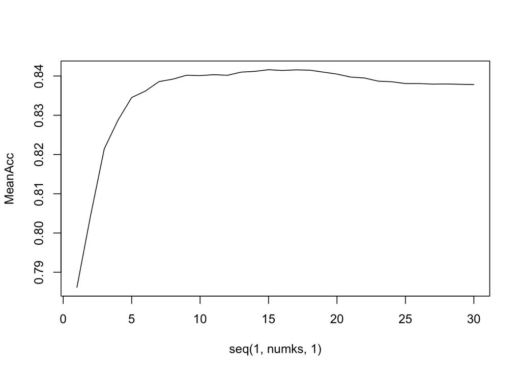

```r
#Now going to loop through more than one k and find the average
iterations = 100
set.seed(6)
numks = 30
masterAcc = matrix(nrow = iterations, ncol = numks)
kkk = c()
Sens = c()
Spec = c()

for(j in 1:iterations)
{
trainIndices = sample(1:dim(case)[1], round(splitPerc * dim(case)[1]))
train = case[trainIndices,]
test = case[-trainIndices,]
for(i in 1:numks)
  {
    classifications = knn(train[,2:4], test[,2:4], train$Attrition, prob = TRUE, k = i)
    table(test$Attrition, classifications)
    CM = confusionMatrix(table(test$Attrition, classifications))
    masterAcc[j,i] = CM$overall[1]
    kkk[i] = CM$overall[1]
    Sens[i] = CM$byClass[1]
    Spec[i] = CM$byClass[2]
  }
}
MeanAcc = colMeans(masterAcc)
plot(seq(1,numks,1),MeanAcc, type = "l")
```

```r
combo = data_frame(k = 1:30,Sensitivity = Sens, Specificity = Spec, MeanAcc)
mean(combo$MeanAcc[1:26])
```

```
## [1] 0.8350958
```

```r
mean(combo$Specificity[1:19])
```

```
## [1] 0.6611016
```

```r
mean(combo$Sensitivity[1:26])
```

```
## [1] 0.8637354
```

## Monthly Income Linear Regression

As per the intial analysis and EDA, we have what we need to create a linear regression model that would give us the best prediction for monthly salary. To reiterate the following independent variables were chosen to be represented in the model to predict monthly income: - Total Working Years - Age - Years at Company - Job Level

```r
#linear models for Salaries (on attrition data before the split)
#Pre-liminary models
reg = lm(MonthlyIncome~Education, attritionData)
reg2 = lm(MonthlyIncome~TotalWorkingYears, attritionData)
#Main Model
mReg = lm(MonthlyIncome~TotalWorkingYears + Age + YearsAtCompany + JobLevel, attritionData)

#Test with just two observations
df = data.frame(TotalWorkingYears = 10, Education = 4)
#Create new Data Frame with just experience and education to predict salary for each person
EduTotal = noSalaryData %>% select(ID,TotalWorkingYears, Age, YearsAtCompany, JobLevel)
#Prediction
pred2 = predict(mReg, newdata = EduTotal)

#Residual Sum of Squares
RSS = c(crossprod(mReg$residuals))
#Mean Squared Error
MSE = RSS / length(mReg$residuals)
#Root MSE
RMSE = sqrt(MSE)

RMSE
```

```
## [1] 1379.235
```

```r
#New Column with Preds
EduTotal$MonthlySalary = pred2
EduTotal$MonthlySalary = as.integer(EduTotal$MonthlySalary)

Final_CSV_Linear = EduTotal %>% select(ID, MonthlySalary)

#Writing predictions to CSV
#write.csv(Final_CSV_Linear, file = "Case2PredictionsVankina Salary.csv")

#Validation Set
vReg = lm(MonthlySalary~TotalWorkingYears + Age + YearsAtCompany + JobLevel, EduTotal)
vReg
```

```
##
## Call:
## lm(formula = MonthlySalary ~ TotalWorkingYears + Age + YearsAtCompany +
##     JobLevel, data = EduTotal)
##
## Coefficients:
##       (Intercept)  TotalWorkingYears                Age
##         -1697.428             73.062             -2.319
##    YearsAtCompany           JobLevel
##           -32.749           3723.760
```

```r
confint(vReg)
```

```
##                          2.5 %       97.5 %
## (Intercept)       -1697.584053 -1697.272927
## TotalWorkingYears    73.053027    73.070262
## Age                  -2.323776    -2.313696
## YearsAtCompany      -32.757138   -32.741384
## JobLevel           3723.708314  3723.811082
```

```r
#Residual Sum of Squares
RSS_V = c(crossprod(vReg$residuals))
#Mean Squared Error
MSE_V = RSS_V / length(vReg$residuals)
#Root MSE
RMSE_V = sqrt(MSE_V)

RMSE_V
```

```
## [1] 0.2872739
```

## Conclusion

To conclude, the data set itself was a little bit difficult to work with. There were far more numerical variable then there were categorical variables. From the initial analysis we found the variables that we needed to test attrition and monthly salary. Predicting the salary was straightforward as there is many correlation for montly income and other variables the can be used to predict income. We also found some interesting information and trends within this data. Attrition was a little bit difficult to classify correctly, as the attrition data not proportional. There was far less turnover/attrition in the company, which made classification difficult but not impossible. Overall we achieved the following: RMSE < 3000 60/60 Sensitivity and Specificity rate for Attrition.